# Problem Definition

- This project seeks to predict the best location for purchasing housing property in Nigeria, based on budget and order features using machine learning.
- The project at hand is a classification problem. Since it aims at predicting a categorical outcome (town), which is the Town based on numerical and categorical features such as price, title, bathrooms, bedrooms, and parking space.

## Data

Data for this project will be obtained from the online platform 'Kaggle.com'

## Data Dictionary (Features and Target Variable)

### Dataset Includes:

The following features will be used to predict our target variable (Predicted Town) in our project:

**Title (string)** - The house type e.g Semi-Detached Duplex, Detached Duplex, Bongalow ..

**Parking Space (int)** - The number of parking spaces within the property e.g 1, 2, 3, 4, ..

**Bedrooms (int)** - The number of bedrooms in the house e.g 1, 2, 3, 4, ..

**Bathrooms (int)** - The total number of bathroom in each house e.g 1, 2, 3, 4, ..

**State (string)** - The name of state of each house or the sate where the house is located. i.e Abuja, Lagos, Ogun ..

**Price (float)** - The total amount or price of each house e.g 2.7, 1.0. 2000.00, (million) ..

**Toilet (int)** - The total number of toilet in each house e.g 1, 2, 3, 4, ...

**Town (string)** - The name of the town where the house are built. i.e Lekki, Wuye, Jahi, ..

**NB:** Town will be our target variable in this instance.

```python
import pandas as pd
```

## Data Cleaning

```python
data = pd.read_csv("nigeria_houses_data_new.csv")
data
```

|  | bedrooms | bathrooms | toilets | parking_space | title | town | state | price |
| --- | --- | --- | --- | --- | --- | --- | --- | --- |
| 0 | 6.0 | 5.0 | 5.0 | 4.0 | Detached Duplex | Mabushi | Abuja | 450000000.0 |
| 1 | 4.0 | 5.0 | 5.0 | 4.0 | Terraced Duplexes | Katampe | Abuja | 800000000.0 |
| 2 | 4.0 | 5.0 | 5.0 | 4.0 | Detached Duplex | Lekki | Lagos | 120000000.0 |
| 3 | 4.0 | 4.0 | 5.0 | 6.0 | Detached Duplex | Ajah | Lagos | 40000000.0 |
| 4 | 4.0 | 4.0 | 5.0 | 2.0 | Semi Detached Duplex | Lekki | Lagos | 75000000.0 |
| ... | ... | ... | ... | ... | ... | ... | ... | ... |
| 24321 | 2.0 | 2.0 | 2.0 | 4.0 | Block of Flats | Kabusa | Abuja | 15000000.0 |
| 24322 | 4.0 | 5.0 | 5.0 | 4.0 | Block of Flats | Ado-Odo/Ota | Ogun | 25000000.0 |
| 24323 | 4.0 | 5.0 | 5.0 | 4.0 | Detached Duplex | Lekki | Lagos | 68000000.0 |
| 24324 | 3.0 | 4.0 | 4.0 | 3.0 | Block of Flats | Victoria Island (VI) | Lagos | 78000000.0 |
| 24325 | 4.0 | 5.0 | 5.0 | 4.0 | Detached Duplex | Lekki | Lagos | 65000000.0 |

24326 rows × 8 columns

```python
# Checking for baasic info about the dataset
data.info()
```

```
<class 'pandas.core.frame.DataFrame'>
RangeIndex: 24326 entries, 0 to 24325
Data columns (total 8 columns):
 #   Column         Non-Null Count  Dtype
---  ------         --------------  -----
 0   bedrooms       24326 non-null  float64
 1   bathrooms      24326 non-null  float64
 2   toilets        24326 non-null  float64
 3   parking_space  24326 non-null  float64
 4   title          24326 non-null  object
 5   town           24326 non-null  object
 6   state          24326 non-null  object
 7   price          24326 non-null  float64
dtypes: float64(5), object(3)
memory usage: 1.5+ MB
```

### Checking for missing values in the dataset

```python
# Checking for missing values in the dataset
missing_values = data.isnull().sum()
print(missing_values)
```

```
bedrooms         0
bathrooms        0
toilets          0
parking_space    0
title            0
town             0
state            0
price            0
dtype: int64
```

```python
# Create a new column 'price_millions' that is the price in millions

data['price_millions'] = data['price']/1000000

# Remove the original 'price' column
data.drop(columns=['price'], inplace=True)
```

```python
data.head()
```

|  | bedrooms | bathrooms | toilets | parking_space | title | town | state | price_millions |
| --- | --- | --- | --- | --- | --- | --- | --- | --- |
| 0 | 6.0 | 5.0 | 5.0 | 4.0 | Detached Duplex | Mabushi | Abuja | 450.0 |
| 1 | 4.0 | 5.0 | 5.0 | 4.0 | Terraced Duplexes | Katampe | Abuja | 800.0 |
| 2 | 4.0 | 5.0 | 5.0 | 4.0 | Detached Duplex | Lekki | Lagos | 120.0 |
| 3 | 4.0 | 4.0 | 5.0 | 6.0 | Detached Duplex | Ajah | Lagos | 40.0 |
| 4 | 4.0 | 4.0 | 5.0 | 2.0 | Semi Detached Duplex | Lekki | Lagos | 75.0 |

## Exploratory Data Analysis and Visualization

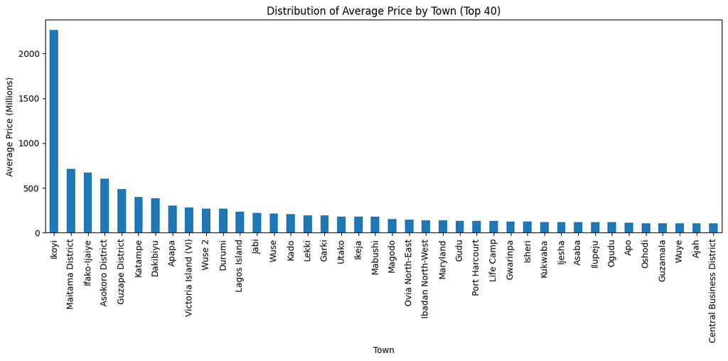

```python
import matplotlib.pyplot as plt

# Group by town and calculate the average price
town_price_distribution = data.groupby('town')['price_millions'].mean().sort_values(ascending=False)

# Select the top 40 towns of the calculated average price
top_40_towns = town_price_distribution.head(40)

# Create the bar chart for the average price for the top 40 towns
plt.figure(figsize=(12, 6))
top_40_towns.plot(kind='bar')
plt.title('Distribution of Average Price by Town (Top 40)')
plt.xlabel('Town')
plt.ylabel('Average Price (Millions)')
plt.xticks(rotation=90)
plt.tight_layout()
plt.show()
```

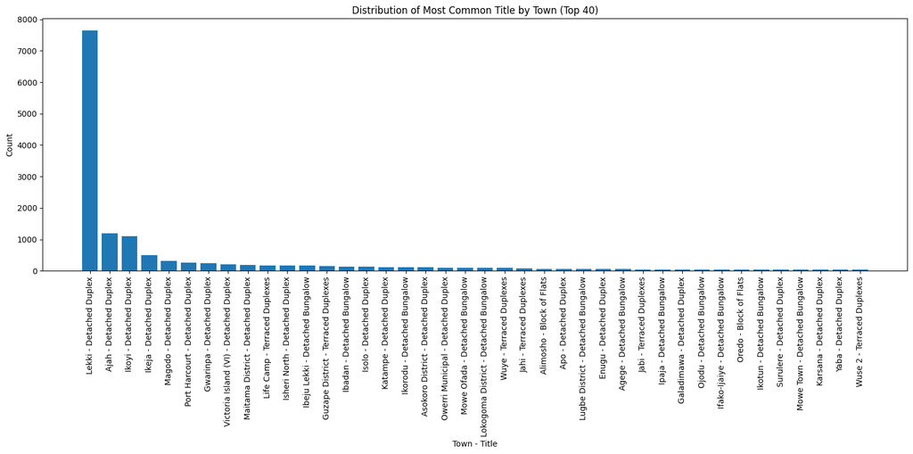

```python
# Group by town - title and calculate the average price
town_title_counts = data.groupby(['town', 'title']).size().reset_index(name='counts')

# Finding the most common title for each town
most_common_title_per_town = town_title_counts.loc[town_title_counts.groupby('town')['counts'].idxmax()]

# Sort by count to get the towns with the most occurrences of the most common title
most_common_title_per_town = most_common_title_per_town.sort_values('counts', ascending=False)

# Select the top 40 towns based on the most common title
top_40_towns_titles = most_common_title_per_town.head(40)

# Create the bar chart
plt.figure(figsize=(16, 8))
plt.bar(top_40_towns_titles['town'] + ' - ' + top_40_towns_titles['title'], top_40_towns_titles['counts'])
plt.title('Distribution of Most Common Title by Town (Top 40)')
plt.xlabel('Town - Title')
plt.ylabel('Count')
plt.xticks(rotation=90)
plt.tight_layout()
plt.show()
```

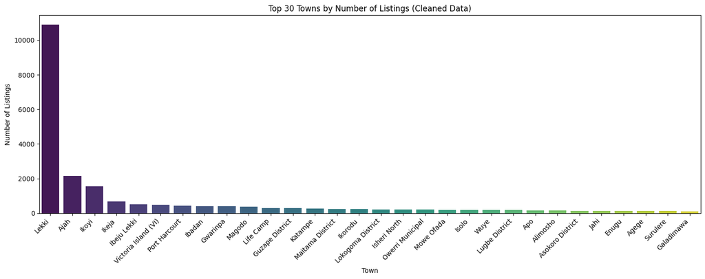

|  | price_millions | bedrooms | bathrooms | toilets | parking_space |
| --- | --- | --- | --- | --- | --- |
| count | 2.432600e+04 | 24326.000000 | 24326.000000 | 24326.000000 | 24326.000000 |
| mean | 3.013802e+02 | 4.338814 | 4.600798 | 5.176355 | 4.041725 |
| std | 1.220403e+04 | 1.138497 | 1.163161 | 1.226253 | 1.399936 |
| min | 9.000000e-02 | 1.000000 | 1.000000 | 1.000000 | 1.000000 |
| 25% | 5.200000e+01 | 4.000000 | 4.000000 | 5.000000 | 4.000000 |
| 50% | 8.500000e+01 | 4.000000 | 5.000000 | 5.000000 | 4.000000 |
| 75% | 1.600000e+02 | 5.000000 | 5.000000 | 6.000000 | 4.000000 |
| max | 1.800000e+06 | 9.000000 | 9.000000 | 9.000000 | 9.000000 |

```python
import matplotlib.pyplot as plt
import seaborn as sns

# Define the numerical features
numerical_features = ['price_millions', 'bedrooms', 'bathrooms', 'toilets', 'parking_space']



# Step 3: Visualize the distribution of towns again after cleaning
town_counts_cleaned = data['town'].value_counts()

# Plot the bar chart
plt.figure(figsize=(15, 6))
sns.barplot(
    x=town_counts_cleaned.index[:30],
    y=town_counts_cleaned.values[:30],
    palette='viridis',
    hue=town_counts_cleaned.index[:30]
)


# Remove legend and other enhancements
plt.legend([], [], frameon=False)
plt.xticks(rotation=45, ha='right')
plt.title("Top 30 Towns by Number of Listings (Cleaned Data)")
plt.xlabel("Town")
plt.ylabel("Number of Listings")
plt.tight_layout()

plt.show()

# Display descriptive statistics for verification
data[numerical_features].describe()
```

## Here’s what we observe after carrying out exploratory data analysis:

Town Distribution:

- The cleaned data still shows an imbalance in the number of listings across towns, which may affect our model's performance.

Numerical Features:

```python
# Calculate the 15th and 85th percentiles of the price column

q1, q9 = data["price_millions"].quantile([0.15,0.85])


#Create a boolean mask where prices in the respective towns is between the 15th and 85th percentiles

mask_data = data["price_millions"].between(q1, q9)

# Filter the dataset using the mask to retain rows within the specified price range

trimmed_data = data[mask_data]
trimmed_data
```

|  | bedrooms | bathrooms | toilets | parking_space | title | town | state | price_millions |
| --- | --- | --- | --- | --- | --- | --- | --- | --- |
| 2 | 4.0 | 5.0 | 5.0 | 4.0 | Detached Duplex | Lekki | Lagos | 120.0 |
| 3 | 4.0 | 4.0 | 5.0 | 6.0 | Detached Duplex | Ajah | Lagos | 40.0 |
| 4 | 4.0 | 4.0 | 5.0 | 2.0 | Semi Detached Duplex | Lekki | Lagos | 75.0 |
| 6 | 4.0 | 5.0 | 5.0 | 4.0 | Detached Duplex | Lekki | Lagos | 65.0 |
| 8 | 1.0 | 1.0 | 1.0 | 1.0 | Detached Duplex | Lekki | Lagos | 200.0 |
| ... | ... | ... | ... | ... | ... | ... | ... | ... |
| 24318 | 4.0 | 5.0 | 5.0 | 4.0 | Semi Detached Duplex | Lekki | Lagos | 110.0 |
| 24320 | 3.0 | 4.0 | 4.0 | 5.0 | Detached Duplex | Lekki | Lagos | 80.0 |
| 24323 | 4.0 | 5.0 | 5.0 | 4.0 | Detached Duplex | Lekki | Lagos | 68.0 |
| 24324 | 3.0 | 4.0 | 4.0 | 3.0 | Block of Flats | Victoria Island (VI) | Lagos | 78.0 |
| 24325 | 4.0 | 5.0 | 5.0 | 4.0 | Detached Duplex | Lekki | Lagos | 65.0 |

17491 rows × 8 columns

```python
records = trimmed_data['town'].value_counts()
records
```

```
town
Lekki                9178
Ajah                 1813
Ikeja                 610
Magodo                360
Gwarinpa              342
                     ...
Oke-Aro                 1
Ikot Ekpene             1
Gwagwalada              1
Ibadan North-East       1
Ido                     1
Name: count, Length: 144, dtype: int64
```

```python
# Dropping values of "towns" that are less than 100
trimmed_data = trimmed_data[~trimmed_data['town'].isin(records[records < 100].index)]
trimmed_data['town'].value_counts()
```

```
town
Lekki                   9178
Ajah                    1813
Ikeja                    610
Magodo                   360
Gwarinpa                 342
Port Harcourt            330
Victoria Island (VI)     302
Ikoyi                    257
Life Camp                254
Guzape District          223
Katampe                  200
Ibadan                   199
Isheri North             198
Ibeju Lekki              193
Owerri Municipal         168
Wuye                     166
Isolo                    164
Lokogoma District        139
Apo                      122
Jahi                     116
Surulere                 106
Name: count, dtype: int64
```

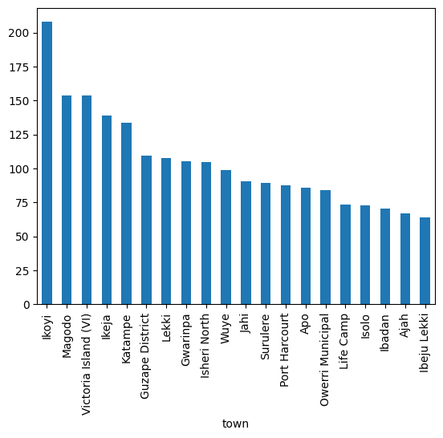

```python
trimmed_data.groupby('town')['price_millions'].mean().sort_values(ascending=False).head(20).plot(kind='bar');
```

# Modelling

```python
import numpy as np
from sklearn.preprocessing import StandardScaler
from sklearn.model_selection import train_test_split, cross_val_score
import pandas as pd
from sklearn.model_selection import train_test_split
from sklearn.linear_model import LogisticRegression
from sklearn.metrics import confusion_matrix, classification_report
from sklearn.preprocessing import LabelEncoder
from sklearn import svm
from sklearn.model_selection import GridSearchCV
```

### Step1: seperating our features(x) from our target(y)

```python
# Step1: seperating our features(x) from our target(y)
X = trimmed_data[['bedrooms', 'bathrooms', 'toilets', 'parking_space', 'title', 'state', 'price_millions']]
y = trimmed_data['town']
```

### Step 2: Encode categorical features

```python
# Step 2.1: Encode categorical features using one-hot encoding for features
X = pd.get_dummies(X, columns=['title', 'state'], drop_first=True)

# Step 2.2: Encode the target variable 'town' using LabelEncoder
label_encoder = LabelEncoder()
y = label_encoder.fit_transform(y)
```

### Step 3: Split the data into training and testing sets

```python
# 3a.1: Split the data into training and testing sets
X_train, X_test, y_train, y_test = train_test_split(X, y, test_size=0.3, stratify=y, random_state=42)

# Step 3b.1: Scale the features using StandardScaler
scaler = StandardScaler()
X_train_scaled = scaler.fit_transform(X_train)
X_test_scaled = scaler.transform(X_test)
```

### **Step 4:** Using models to evaluate

#### 4a. **Random Forest Classifier Model**

```python
from sklearn.ensemble import RandomForestClassifier

# Initialize and train the Random Forest Classifier
rf_classifier = RandomForestClassifier(n_estimators=100, random_state=42)
rf_classifier.fit(X_train_scaled, y_train)

# Make predictions on the test set
y_pred_rf = rf_classifier.predict(X_test_scaled)

# Evaluate the Random Forest model
print("\nRandom Forest Classifier Model")
print(confusion_matrix(y_test, y_pred_rf))
print(classification_report(y_test, y_pred_rf, zero_division=1))
```

```
Random Forest Classifier Model
[[ 249    0    0    1    0    8    7    0    3    3    0    0  264    0
     0    3    0    0    3    3    0]
 [   0    7    3   13    0    0    0    0    0    0    0    2    0    3
     3    0    0    0    0    0    6]
 [   0    1   26   13    0    0    0    0    0    0    2   16    0    4
     1    0    0    0    0    0    4]
 [   0    6    4   60    0    0    0    0    0    0    0    8    0    4
    14    0    0    0    0    0    6]
 [   0    0    0    0   60    0    0    0    0    0    0    0    0    0
     0    0    0    0    0    0    0]
 [  13    0    0    0    0   20    0    0    0    0    0    0   24    0
     0    0    0    0    1    0    0]
 [  17    0    0    0    0    2   21    2    1    4    0    0  126    0
     0    4    0    0    2    4    0]
 [   1    0    0    0    0    1    1   47    0    0    0    0   20    0
     0    0    0    0    1    6    0]
 [   8    0    0    0    0    0    0    0   31    0    0    0   17    0
     0    2    0    0    1    0    0]
 [  10    0    0    0    0    0    2    1    0   22    0    0   12    0
     0    1    0    0    1    0    0]
 [   0    0   11    7    0    0    0    0    0    0    5    1    0    6
     0    0    0    0    0    0    5]
 [   0    2   10    9    0    0    0    0    0    0    2   22    0    1
     3    0    0    0    0    0   11]
 [ 180    0    0    0    0   11   33    7    7    4    0    1 2462    0
     1   15    0    0    9   23    0]
 [   0    7   13   16    0    0    0    0    0    0    0    7    0   20
     4    0    0    0    0    0    9]
 [   0    7    0   11    0    0    0    0    0    0    0    3    0    3
    17    0    0    0    0    0    1]
 [  12    0    0    0    0    0    6    2    9    0    0    0   51    0
     0   26    0    0    0    2    0]
 [   0    0    0    0    0    0    0    0    0    0    0    0    0    0
     0    0   50    0    0    0    0]
 [   0    0    0    0    0    0    0    0    0    0    0    0    0    0
     0    0    0   99    0    0    0]
 [   7    0    0    0    0    0    4    0    0    0    0    0   16    0
     0    0    0    0    5    0    0]
 [   0    0    0    0    0    0    6    9    0    0    0    0   52    0
```

[output cut: 15 more lines]

```
          10       0.42      0.14      0.21        35
          11       0.35      0.37      0.36        60
          12       0.81      0.89      0.85      2753
          13       0.45      0.26      0.33        76
          14       0.39      0.40      0.40        42
          15       0.49      0.24      0.32       108
          16       1.00      1.00      1.00        50
          17       1.00      1.00      1.00        99
          18       0.22      0.16      0.18        32
          19       0.37      0.24      0.29        91
          20       0.32      0.40      0.36        50

    accuracy                           0.71      4632
   macro avg       0.52      0.47      0.48      4632
weighted avg       0.69      0.71      0.69      4632
```

#### **4b:** Logistic classifier Model (Logistic Regression)

```python
# Step 4a.1: Initialize and train the logistic regression model
logistic_classifier = LogisticRegression(max_iter=500)
logistic_classifier.fit(X_train_scaled, y_train)

# Step 4a.2: Make predictions on the test set
y_pred = logistic_classifier.predict(X_test_scaled)

# Step 4a.3: Evaluate the model
print("\nLogistic Classifier Model")
print(confusion_matrix(y_test, y_pred))
print(classification_report(y_test, y_pred, zero_division=1))
```

```
Logistic Classifier Model
[[  56    0    0    0    0    5    0    2    0    1    0    0  480    0
     0    0    0    0    0    0    0]
 [   0    2    2   16    0    0    0    0    0    0    1    1    0    9
     6    0    0    0    0    0    0]
 [   0    2   29   19    0    0    0    0    0    0    1    2    0   11
     0    0    0    0    0    0    3]
 [   0    7    2   62    0    0    0    0    0    0    1    8    0    9
    11    0    0    0    0    0    2]
 [   0    0    0    0   60    0    0    0    0    0    0    0    0    0
     0    0    0    0    0    0    0]
 [   9    0    0    0    0    0    0    0    0    0    0    0   49    0
     0    0    0    0    0    0    0]
 [  13    0    0    0    0    2    3    7    0    0    0    0  158    0
     0    0    0    0    0    0    0]
 [   0    0    0    0    0    0    0   48    0    0    0    0   29    0
     0    0    0    0    0    0    0]
 [   4    0    0    0    0    0    0    0    5    0    0    0   50    0
     0    0    0    0    0    0    0]
 [   3    0    0    0    0    0    0    0    0   22    0    0   23    0
     0    0    0    0    1    0    0]
 [   0    0    9    3    0    0    0    0    0    0    4    2    0   16
     0    0    0    0    0    0    1]
 [   0    0   13   15    0    0    0    0    0    0    0   17    0   10
     2    0    0    0    0    0    3]
 [  38    0    0    0    0    0    0    6    0    0    0    0 2708    0
     0    0    0    0    1    0    0]
 [   0    2   13   11    0    0    0    0    0    0    0    1    0   41
     8    0    0    0    0    0    0]
 [   0    3    0   19    0    0    0    0    0    0    0    0    0    4
    16    0    0    0    0    0    0]
 [   2    0    0    0    0    1    0    1    0    0    0    0  103    0
     0    0    0    0    1    0    0]
 [   0    0    0    0    0    0    0    0    0    0    0    0    0    0
     0    0   50    0    0    0    0]
 [   0    0    0    0    0    0    0    0    0    0    0    0    0    0
     0    0    0   99    0    0    0]
 [   2    0    0    0    0    0    1    1    0    1    0    0   23    0
     0    0    0    0    4    0    0]
 [   0    0    0    0    0    0    0    8    0    0    0    0   82    0
```

[output cut: 15 more lines]

```
          10       0.50      0.11      0.19        35
          11       0.49      0.28      0.36        60
          12       0.73      0.98      0.84      2753
          13       0.34      0.54      0.42        76
          14       0.36      0.38      0.37        42
          15       1.00      0.00      0.00       108
          16       1.00      1.00      1.00        50
          17       1.00      1.00      1.00        99
          18       0.57      0.12      0.21        32
          19       1.00      0.01      0.02        91
          20       0.31      0.08      0.13        50

    accuracy                           0.70      4632
   macro avg       0.62      0.38      0.39      4632
weighted avg       0.68      0.70      0.62      4632
```

#### **4c:** Support Vector Machine (SVM) Model

```python
# Step 4.1: Initialize and train the SVM model
svm_classifier = svm.SVC(kernel='linear', C=1,gamma='auto')
svm_classifier.fit(X_train_scaled, y_train)

# Step 4.2: Make predictions on the test set
y_pred_svm = svm_classifier.predict(X_test_scaled)

# Step 4b.3: Evaluate the SVM model
print("\nSupport Vector Machine (SVM) Model")
print(confusion_matrix(y_test, y_pred_svm))
print(classification_report(y_test, y_pred_svm, zero_division=1))
```

```
Support Vector Machine (SVM) Model
[[  33    0    0    1    0    0    0    2    0    0    0    0  508    0
     0    0    0    0    0    0    0]
 [   0    0    2   27    0    0    0    0    0    0    1    1    0    5
     1    0    0    0    0    0    0]
 [   0    0   30   26    0    0    0    0    0    0    2    1    0    8
     0    0    0    0    0    0    0]
 [   0    1    1   74    0    0    0    0    0    0    2    7    0    7
    10    0    0    0    0    0    0]
 [   0    0    0    0   60    0    0    0    0    0    0    0    0    0
     0    0    0    0    0    0    0]
 [   8    0    0    0    0    0    0    0    0    0    0    0   50    0
     0    0    0    0    0    0    0]
 [   9    0    0    0    0    0    1    0    0    0    0    0  173    0
     0    0    0    0    0    0    0]
 [   0    0    0    0    0    0    0   50    0    0    0    0   27    0
     0    0    0    0    0    0    0]
 [   0    0    0    0    0    0    0    0    5    0    0    0   54    0
     0    0    0    0    0    0    0]
 [   1    0    0    0    0    0    0    0    0   21    0    0   27    0
     0    0    0    0    0    0    0]
 [   0    0    9    3    0    0    0    0    0    0    5    2    0   16
     0    0    0    0    0    0    0]
 [   0    0   14   25    0    0    0    0    0    0    1   13    0    7
     0    0    0    0    0    0    0]
 [  12    0    0    1    0    0    0    7    0    0    0    0 2733    0
     0    0    0    0    0    0    0]
 [   0    0   13   29    0    0    0    0    0    0    0    1    0   32
     1    0    0    0    0    0    0]
 [   0    0    0   30    0    0    0    0    0    0    0    0    0    3
     9    0    0    0    0    0    0]
 [   1    0    0    0    0    0    0    1    0    0    0    0  106    0
     0    0    0    0    0    0    0]
 [   0    0    0    0    0    0    0    0    0    0    0    0    0    0
     0    0   50    0    0    0    0]
 [   0    0    0    0    0    0    0    0    0    0    0    0    0    0
     0    0    0   99    0    0    0]
 [   6    0    0    0    0    0    0    1    0    0    0    0   25    0
     0    0    0    0    0    0    0]
 [   0    0    0    0    0    0    0   10    0    0    0    0   81    0
```

[output cut: 15 more lines]

```
          10       0.38      0.14      0.21        35
          11       0.52      0.22      0.31        60
          12       0.72      0.99      0.84      2753
          13       0.33      0.42      0.37        76
          14       0.41      0.21      0.28        42
          15       1.00      0.00      0.00       108
          16       1.00      1.00      1.00        50
          17       1.00      1.00      1.00        99
          18       1.00      0.00      0.00        32
          19       1.00      0.00      0.00        91
          20       1.00      0.00      0.00        50

    accuracy                           0.69      4632
   macro avg       0.73      0.35      0.35      4632
weighted avg       0.71      0.69      0.60      4632
```

### 4d. K-Nearest Neighbors model

```python
from sklearn.neighbors import KNeighborsClassifier

# Initialize and train the K-Nearest Neighbors Classifier
knn_classifier = KNeighborsClassifier(n_neighbors=5)
knn_classifier.fit(X_train_scaled, y_train)

# Make predictions on the test set
y_pred_knn = knn_classifier.predict(X_test_scaled)

# Evaluate the K-Nearest Neighbors model
print("\nK-Nearest Neighbors Classifier Model")
print(confusion_matrix(y_test, y_pred_knn))
print(classification_report(y_test, y_pred_knn, zero_division=1))
```

```
K-Nearest Neighbors Classifier Model
[[ 225    0    0    0    0    6    5    0    3    3    0    0  299    0
     0    0    0    0    2    1    0]
 [   0    6    2   19    0    0    0    0    0    0    0    0    0    5
     2    0    0    0    0    0    3]
 [   0    5   32    8    0    0    0    0    0    0    2    7    1    5
     1    0    0    0    0    0    6]
 [   2   15    4   51    0    0    0    0    0    0    3    6    0    6
    10    0    0    0    0    0    5]
 [   0    0    0    0   60    0    0    0    0    0    0    0    0    0
     0    0    0    0    0    0    0]
 [  14    0    0    0    0   19    0    0    0    0    0    0   25    0
     0    0    0    0    0    0    0]
 [  26    0    0    0    0    1   21    2    2    3    0    0  122    0
     0    4    0    0    0    2    0]
 [   0    0    0    0    0    0    2   46    0    1    0    0   22    0
     0    1    0    0    0    5    0]
 [   8    0    0    0    0    1    2    0   25    3    0    0   20    0
     0    0    0    0    0    0    0]
 [   8    0    0    0    0    1    4    0    1   22    0    0   12    0
     0    0    0    0    1    0    0]
 [   0    2   13    2    0    0    0    0    0    0    4    1    0    7
     1    0    0    0    0    0    5]
 [   0    6   11   11    0    0    0    0    0    0    4   14    0    2
     1    0    0    0    0    0   11]
 [ 210    0    0    0    0    4   30   11   15    5    0    0 2457    0
     0   12    0    0    2    7    0]
 [   1   10   11   17    0    0    0    0    0    0    2    3    0   17
     3    0    0    0    0    0   12]
 [   0    7    0   16    0    0    0    0    0    0    0    1    0    3
    13    0    0    0    0    0    2]
 [  11    0    0    0    0    0    3    2    9    2    0    0   57    0
     0   23    0    0    0    1    0]
 [   1    0    0    0    0    0    0    0    0    0    0    0    1    0
     1    0   47    0    0    0    0]
 [   1    0    0    0    0    0    0    0    0    0    0    0    0    0
     1    0    0   97    0    0    0]
 [   9    0    0    0    0    1    5    0    1    1    0    0   13    0
     0    0    0    0    2    0    0]
 [   1    0    0    0    0    0    1    6    0    0    0    0   70    0
```

[output cut: 15 more lines]

```
          10       0.21      0.11      0.15        35
          11       0.39      0.23      0.29        60
          12       0.79      0.89      0.84      2753
          13       0.31      0.22      0.26        76
          14       0.38      0.31      0.34        42
          15       0.56      0.21      0.31       108
          16       1.00      0.94      0.97        50
          17       1.00      0.98      0.99        99
          18       0.29      0.06      0.10        32
          19       0.43      0.13      0.20        91
          20       0.20      0.22      0.21        50

    accuracy                           0.69      4632
   macro avg       0.50      0.42      0.44      4632
weighted avg       0.66      0.69      0.67      4632
```

### **Step 5:** Hyperparameters Tuning

Hyperparameter tuning in this case will focus on uncreasing the **'n_estimator'** in the **Random Forest Classifier Model**, since it is the model we will be working with.

#### Hyperparameter Explanation

**'n_estimators':** The number of tree in the forest. More tree can improve performance but may increase computational time.

```python
# initialize RandomForestRegressor with default parameters
rfc_model = RandomForestClassifier()

# Display the default parameters
(rfc_model.get_params())
```

```
{'bootstrap': True,
 'ccp_alpha': 0.0,
 'class_weight': None,
 'criterion': 'gini',
 'max_depth': None,
 'max_features': 'sqrt',
 'max_leaf_nodes': None,
 'max_samples': None,
 'min_impurity_decrease': 0.0,
 'min_samples_leaf': 1,
 'min_samples_split': 2,
 'min_weight_fraction_leaf': 0.0,
 'monotonic_cst': None,
 'n_estimators': 100,
 'n_jobs': None,
 'oob_score': False,
 'random_state': None,
 'verbose': 0,
 'warm_start': False}
```

#### **5a:** Train Random Forest with increased *'n_estimators'* from 100 to 500.

```python
from sklearn.ensemble import RandomForestClassifier

# Initialize and train the Random Forest Classifier
rf_classifier = RandomForestClassifier(n_estimators=500, random_state=42)
rf_classifier.fit(X_train_scaled, y_train)

# Make predictions on the test set
y_pred_rf = rf_classifier.predict(X_test_scaled)

# Evaluate the Random Forest model
print("\nRandom Forest Classifier Model")
print(confusion_matrix(y_test, y_pred_rf))
print(classification_report(y_test, y_pred_rf, zero_division=1))
```

```
Random Forest Classifier Model
[[ 240    0    0    1    0    8    6    0    2    3    0    0  273    0
     0    6    0    0    2    3    0]
 [   0    4    2   14    0    0    0    0    0    0    0    2    0    6
     4    0    0    0    0    0    5]
 [   0    1   24   13    0    0    0    0    0    0    2   15    0    6
     1    0    0    0    0    0    5]
 [   0    6    4   57    0    0    0    0    0    0    1    8    0    4
    16    0    0    0    0    0    6]
 [   0    0    0    0   60    0    0    0    0    0    0    0    0    0
     0    0    0    0    0    0    0]
 [  10    0    0    0    0   20    0    0    0    0    0    0   27    0
     0    0    0    0    1    0    0]
 [  18    0    0    0    0    2   21    2    1    4    0    0  127    0
     0    4    0    0    1    3    0]
 [   1    0    0    0    0    1    1   47    0    0    0    0   20    0
     0    0    0    0    1    6    0]
 [   8    0    0    0    0    0    0    0   31    0    0    0   16    0
     0    3    0    0    1    0    0]
 [   9    0    0    0    0    0    2    1    0   22    0    0   13    0
     0    1    0    0    1    0    0]
 [   0    1   11    6    0    0    0    0    0    0    6    1    0    5
     0    0    0    0    0    0    5]
 [   0    2   10    9    0    0    0    0    0    0    2   21    0    1
     3    0    0    0    0    0   12]
 [ 180    0    0    0    0   10   28    7    7    4    0    1 2457    0
     1   14    0    0   10   34    0]
 [   0    5   13   16    0    0    0    0    0    0    0    6    0   22
     3    0    0    0    0    0   11]
 [   0    6    0   14    0    0    0    0    0    0    0    1    0    2
    18    0    0    0    0    0    1]
 [  13    0    0    0    0    0    6    2    9    0    0    0   50    0
     0   27    0    0    0    1    0]
 [   0    0    0    0    0    0    0    0    0    0    0    0    0    0
     0    0   50    0    0    0    0]
 [   0    0    0    0    0    0    0    0    0    0    0    0    0    0
     0    0    0   99    0    0    0]
 [   6    0    0    0    0    0    4    0    0    0    0    0   15    0
     0    0    0    0    7    0    0]
 [   0    0    0    0    0    0    2    9    0    0    0    0   55    0
```

[output cut: 15 more lines]

```
          10       0.40      0.17      0.24        35
          11       0.38      0.35      0.36        60
          12       0.80      0.89      0.85      2753
          13       0.45      0.29      0.35        76
          14       0.38      0.43      0.40        42
          15       0.47      0.25      0.33       108
          16       1.00      1.00      1.00        50
          17       1.00      1.00      1.00        99
          18       0.29      0.22      0.25        32
          19       0.33      0.25      0.29        91
          20       0.30      0.38      0.33        50

    accuracy                           0.71      4632
   macro avg       0.52      0.46      0.48      4632
weighted avg       0.68      0.71      0.69      4632
```

## Testing the Prediction

We will be testing the output of **Random Forest Classifier** Model, which is the model with the best values for our evaluation metrics.

```python
import pandas as pd
import matplotlib.pyplot as plt
import seaborn as sns
import numpy as np
from sklearn.preprocessing import StandardScaler
from sklearn.model_selection import train_test_split, cross_val_score
from sklearn.ensemble import RandomForestClassifier
from sklearn.metrics import confusion_matrix, classification_report
from sklearn.preprocessing import LabelEncoder


def predict_town(bedrooms, bathrooms, toilets, parking_space, title, state, price_millions):
    """
    Predicts the town based on the input features using the trained logistic regression model.
    Handles exceptions and filters predictions to only include towns within the specified state.
    """
    try:
        # Create a DataFrame with the input features
        input_data = pd.DataFrame({
            'bedrooms': [bedrooms],
            'bathrooms': [bathrooms],
            'toilets': [toilets],
            'parking_space': [parking_space],
            'title': [title],
            'state': [state],
            'price_millions': [price_millions]
        })

        # One-hot encode the categorical features
        input_data = pd.get_dummies(input_data, columns=['title', 'state'], drop_first=True)

        # Align columns with training data
        input_data = input_data.reindex(columns=X_train.columns, fill_value=0)

        # Scale the input features
        input_data_scaled = scaler.transform(input_data)

        # Make the prediction
        predicted_town_encoded = rf_classifier.predict(input_data_scaled)[0]

        # Get all possible towns for the given state from the training data
        state_towns = trimmed_data[trimmed_data['state'] == state]['town'].unique()

        if len(state_towns) == 0 :
          return "No towns found for the given state in the training data."

        # Inverse transform the encoded prediction to get the town name
        predicted_town = label_encoder.inverse_transform([predicted_town_encoded])[0]

        # Check if predicted town belongs to the specified state
        if predicted_town in state_towns:
            return predicted_town
        else:
            # If the predicted town is not in the specified state, find the closest match
            state_encoded_towns = label_encoder.transform(state_towns)
            differences = np.abs(state_encoded_towns - predicted_town_encoded)
            closest_index = np.argmin(differences)
            return state_towns[closest_index]

    except KeyError as e:
        return f"Error: Invalid input feature or state. Check your input. {e}"
    except ValueError as e:
        return f"Error: Invalid input value or data mismatch. {e}"
    except Exception as e:
        return f"An unexpected error occurred: {e}"

# Example usage:
bedrooms = 2
bathrooms = 3
toilets = 4
parking_space = 2
title = "Terraced Duplexes"
state = "Abuja"
price_millions = 400

predicted_town = predict_town(bedrooms, bathrooms, toilets, parking_space, title, state, price_millions)
print(f"Predicted town: {predicted_town}")
```

```
Predicted town: Wuye
```

## Deploying Project to streamlit

### Run the below code to generate the .pkl files in order to use the streamlit framework for deployment

```python
import joblib
joblib.dump(scaler, "scaler.pkl")
joblib.dump(label_encoder, "label_encoder.pkl")
joblib.dump(rf_classifier, "rf_classifier.pkl")
joblib.dump(X_train.columns, "X_train_columns.pkl")
joblib.dump(trimmed_data, "trimmed_data.pkl")
```

```
['trimmed_data.pkl']
```

**Don't forget to install streamlit, using (pip install streamlit) before carrying out the above process**

### Then save the below script as a python file with name

- 'main.py'

###### and run using the command

- 'streamlit run main.py'

```python
pip install streamlit
```

```python
import streamlit as st
import pandas as pd
import numpy as np
import joblib
from sklearn.preprocessing import StandardScaler, LabelEncoder

# Load the trained model and necessary objects
scaler = joblib.load("scaler.pkl")  # Assuming the scaler is saved as 'scaler.pkl'
label_encoder = joblib.load("label_encoder.pkl")  # Assuming label encoder is saved as 'label_encoder.pkl'
random_forest_classifier = joblib.load("rf_classifier.pkl")  # Assuming model is saved as 'logistic_model.pkl'
X_train_columns = joblib.load("X_train_columns.pkl")  # Save X_train.columns for encoding consistency
trimmed_data = joblib.load("trimmed_data.pkl")  # Load training data for state-town mapping

# Streamlit App Title
st.title("🏡 Nigerian House Town Predictor")
st.write("Enter house features to predict the most likely town.")

# User Input Fields
bedrooms = st.number_input("Number of Bedrooms", min_value=1, max_value=10, step=1)
bathrooms = st.number_input("Number of Bathrooms", min_value=1, max_value=10, step=1)
toilets = st.number_input("Number of Toilets", min_value=1, max_value=10, step=1)
parking_space = st.number_input("Parking Space", min_value=0, max_value=10, step=1)
title = st.selectbox("Property Title", ["Detached Duplex", "Semi-Detached Duplex", "Terraced Duplex", "Bungalow", "Penthouse"])
state = st.selectbox("State", ["Lagos", "Abuja", "Kano", "Rivers", "Ogun", "Kaduna"])
price_millions = st.number_input("Price (in millions)", min_value=1.0, step=0.1)

# Prediction Function
def predict_town(bedrooms, bathrooms, toilets, parking_space, title, state, price_millions):
    """
    Predicts the town based on the input features using the trained logistic regression model.
    Handles exceptions and filters predictions to only include towns within the specified state.
    """
    try:
        # Create a DataFrame with the input features
        input_data = pd.DataFrame({
            'bedrooms': [bedrooms],
            'bathrooms': [bathrooms],
            'toilets': [toilets],
            'parking_space': [parking_space],
            'title': [title],
            'state': [state],
            'price_millions': [price_millions]
        })

        # One-hot encode the categorical features
        input_data = pd.get_dummies(input_data, columns=['title', 'state'], drop_first=True)
        input_data = input_data.reindex(columns=X_train_columns, fill_value=0)

        # Scale the input features
        input_data_scaled = scaler.transform(input_data)

        # Make the prediction
        predicted_town_encoded = rf_classifier.predict(input_data_scaled)[0]

        # Get all possible towns for the given state from the training data
        state_towns = trimmed_data[trimmed_data['state'] == state]['town'].unique()

        if len(state_towns) == 0:
            return "No towns found for the given state in the training data."

        # Inverse transform the encoded prediction to get the town name
        predicted_town = label_encoder.inverse_transform([predicted_town_encoded])[0]

        # Check if predicted town belongs to the specified state
        if predicted_town in state_towns:
            return predicted_town
        else:
            # If the predicted town is not in the specified state, find the closest match
            state_encoded_towns = label_encoder.transform(state_towns)
            differences = np.abs(state_encoded_towns - predicted_town_encoded)
            closest_index = np.argmin(differences)
            return state_towns[closest_index]

    except KeyError as e:
        return f"Error: Invalid input feature or state. Check your input. {e}"
    except ValueError as e:
        return f"Error: Invalid input value or data mismatch. {e}"
    except Exception as e:
        return f"An unexpected error occurred: {e}"

# Predict Button
if st.button("Predict Town"):
    result = predict_town(bedrooms, bathrooms, toilets, parking_space, title, state, price_millions)
    st.success(f"🏙️ Predicted Town: {result}")
```